# ds4ps_extra_assignment_01

Alexsandra Cavalcanti

18-05-2022

# Assignment

```r
if (require (tidyverse) == FALSE) {install.packages("tidyverse") ; require (tidyverse)}

if (require (here) == FALSE) {install.packages("here") ; require (here)}

if (require (readxl) == FALSE) {install.packages("readxl") ; require (readxl)}

if (require (devtools) == FALSE) {install.packages("devtools") ; require (devtools)}

if (require (sf) == FALSE) {install.packages("sf") ; require (sf)}

if (require (geobr) == FALSE) {devtools::install_github("ipeaGIT/geobr", subdir = "r-package") ; require (geobr)}

if (require (ggplot2) == FALSE) {install.packages("ggplot2") ; require (ggplot2)}

if (require (rgdal) == FALSE) {install.packages("rgdal") ; require (rgdal)}

theme_set(theme_bw()) # para fundo branco em todos os graficos
```

# 1 Questão

Em 2020, o Brasil e o mundo foram surpreendidos pela onda pandêmica do *Covid-19*. Agora, mais de um ano depois, temos uma grande disponibilidade de dados e podemos observar como cada estado do país está em relação aos números de morte e de casos confirmados. [Brasil em Dados Libertos](https://brasil.io/home/) disponibiliza tais dados.

> - Sua tarefa é construir um mapa por estado através da base de dados `covid19br.xlsx` contida na pasta `data` deste projeto, com o número de **casos confirmados**. Você pode construir o mapa pela *porcentagem* ou pelo *número total* por estados. Além disso, você deve **excluir** os casos sobre o Distrito Federal.

**Não se esqueça de carregar os pacotes necessários.**

Utilize o *code chunk* abaixo para desenvolver sua resposta.

```r
# Primeiro, é preciso carregar e tratar a base de dados.

db <- read_xlsx(here("data", "covid19br.xlsx"))
covid_states_nodf <- db %>%
  filter (state != "DF") %>%
  group_by (state) %>%
  summarise (confirmed_covid_number = sum (confirmed),
             covid_deaths_number = sum (deaths)) %>%
  mutate (confirmed_covid_percentage =
            (confirmed_covid_number / sum (confirmed_covid_number)) * 100,
          covid_deaths_percentage = (covid_deaths_number / sum (covid_deaths_number)) * 100)

# Segundo, é preciso carregar e tratar a base de dados acerca dos estados brasileiros.

brmap_nodf <- read_state (year=2020) %>%
  rename ("state" = abbrev_state) %>%
  filter (state != "DF")

# Terceiro, é preciso juntar as bases de dados.

data_nodf <- brmap_nodf %>% full_join (covid_states_nodf, by = "state")
```

## 1.1 Pela %

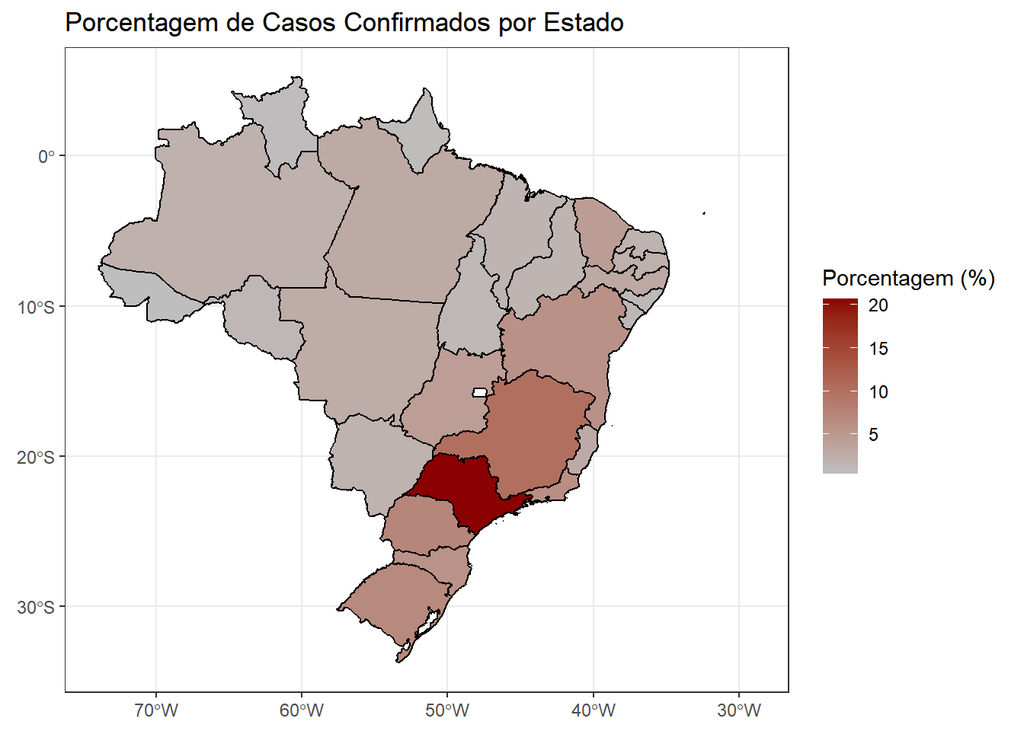

```r
ggplot (data_nodf) +
  geom_sf (aes (geometry = geom, fill = confirmed_covid_percentage), color = "black") +
  coord_sf () +
  scale_fill_gradient(low="grey", high="darkred") +
  theme(legend.position = "right", legend.title.align=0.5) +
  labs (title = "Porcentagem de Casos Confirmados por Estado",
        fill = "Porcentagem (%)")
```

## 1.2 Pelo N total

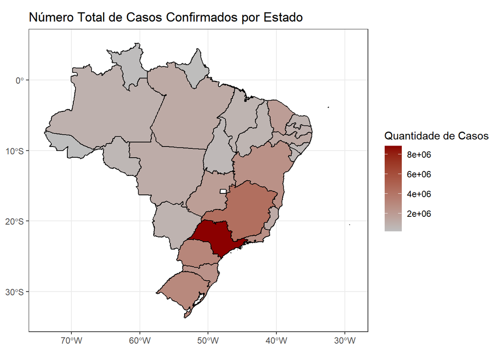

```r
ggplot (data_nodf) +
  geom_sf (aes (geometry = geom, fill = confirmed_covid_number), color = "black") +
  coord_sf () +
  scale_fill_gradient(low="grey", high="darkred") +
  theme(legend.position = "right", legend.title.align=0.5) +
  labs (title = "Número Total de Casos Confirmados por Estado",
        fill = "Quantidade de Casos")
```

De acordo com os dados, qual o estado com o maior número ou porcentagem de casos confirmados por Covid-19? Apresente sua resposta com o código embutido em seu texto.

**Resposta:**

- ```
    O estado com maior número e porcentagem de casos confirmados de Covid-19 é SP.
  ```

# 2 Questão

Ainda sobre os dados de Covid-19, `covid19br.xlsx`, responda as seguintes perguntas:

> - Qual a **média** de casos confirmados e de mortes por município? Apresente sua resposta com o código embutido em seu texto.

```r
covid_per_mun <- db %>%
  filter (place_type == "city",
          city != "Importados/Indefinidos") %>%
  select (city, confirmed, deaths) %>%
  drop_na ()
```

**Resposta:**

- ```
    A média de casos confirmados por município identificado é 3.881,25.
  ```

- ```
    A média de mortes por município identificado é 108.
  ```

> - Qual o valor mínimo de casos confirmados? Apresente sua resposta com o código embutido em seu texto.

**Resposta:**

- ```
    O mínimo de casos confirmados em um município identificado é de 10, referente à cidade de Miravânia.
  ```

> - Qual o valor máximo de casos confirmados? Apresente sua resposta com o código embutido em seu texto.

**Resposta:**

- ```
    O máximo de casos confirmados em um município identificado é de 969604, referente à cidade de São Paulo.
  ```

# 3 Questão

Apresente visualmente o resultado *percentual* de casos confirmados e de mortes por Covid-19 por estado. Se conseguir, faça numa única visualização:

Utilize o *code chunk* abaixo para desenvolver sua resposta. Se necessário, crie outros *code chunks*.

- Percentual de casos confirmados por estado:

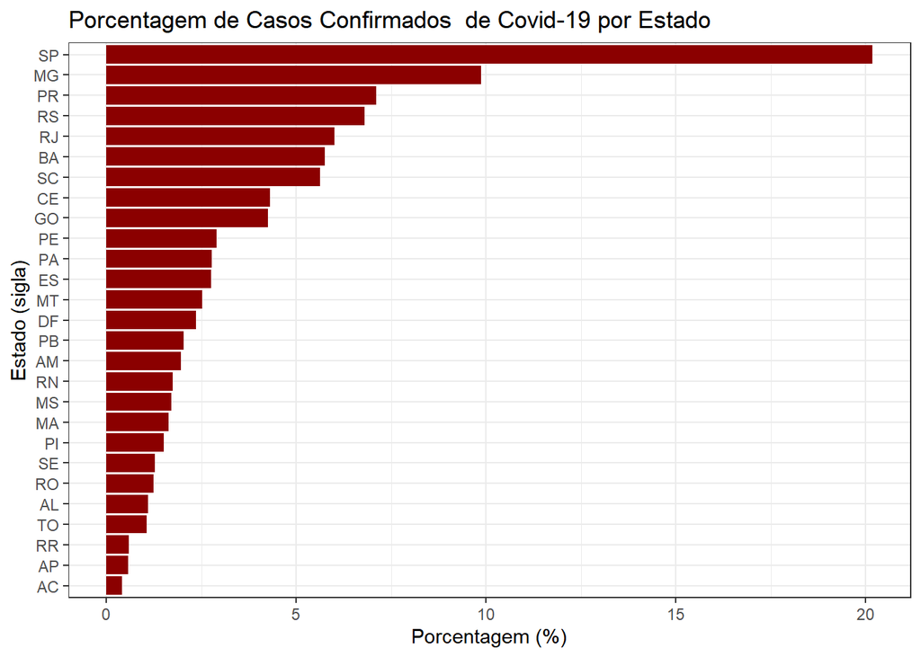

```r
# Primeiro, é preciso contar com uma nova base de dados para os estados que não exclua o Distrito Federal.

data_states <- db %>%
  group_by (state) %>%
  summarise (confirmed_covid_number = sum (confirmed),
             covid_deaths_number = sum (deaths)) %>%
  mutate (confirmed_covid_percentage =
            (confirmed_covid_number / sum (confirmed_covid_number)) * 100,
          covid_deaths_percentage = (covid_deaths_number / sum (covid_deaths_number)) * 100)

# Em seguida, torna-se possível fazer a representação visual solicitada.

data_states %>%
  ggplot () +
  geom_col (mapping = aes (x  = reorder (state, +confirmed_covid_percentage),
                           y = confirmed_covid_percentage),
            fill = "darkred") +
  coord_flip () +
  labs (title = "Porcentagem de Casos Confirmados  de Covid-19 por Estado",
        y = "Porcentagem (%)",
        x = "Estado (sigla)")
```

- Percentual de mortes por estado

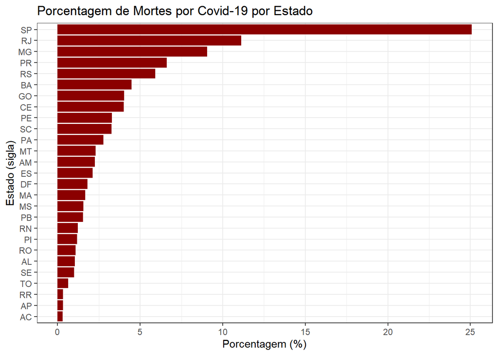

```r
data_states %>%
  ggplot () +
  geom_col (mapping = aes (x  = reorder (state, +covid_deaths_percentage),
                           y = covid_deaths_percentage),
            fill = "darkred") +
  coord_flip () +
  labs (title = "Porcentagem de Mortes por Covid-19 por Estado",
        y = "Porcentagem (%)",
        x = "Estado (sigla)")
```